# Systematic Literature Search: Telomere Dynamics and Reproductive Investment

Agnes Szwarczynska

2026-04-15

# 1 Overview

This document describes the systematic literature search pipeline for the **Telomeres Project**. The workflow follows a semi-automated approach using the `litsearchr` package to:

1. Extract candidate search terms from a set of *gold standard* papers.
2. Build a co-occurrence network to identify the most informative terms.
3. Construct a Boolean search string.
4. Merge and deduplicate results from multiple databases (Web of Science, Scopus, and PubMed).
5. Validate that all gold standard papers are retained throughout the screening process.

# 2 Required Packages

The following packages are required. Install any missing packages with `install.packages()` before proceeding.

```r
library(ggplot2)     # Data visualisation
library(ggraph)      # Network graph visualisation
library(igraph)      # Network analysis
library(readr)       # Reading rectangular data
library(readxl)      # Reading Excel files
library(dplyr)       # Data manipulation
library(litsearchr)  # Automated literature search
```

# 3 Importing Gold Standard Papers

A set of *gold standard* papers — publications known *a priori* to be relevant to the research question — is used to guide automated term extraction. These papers are imported from a `.ris` reference file.

```r
gold_standard <- litsearchr::import_results(file = "../data/gold_search.ris")
```

```
## Reading file ../data/gold_search.ris ... done
```

# 4 Keyword Extraction

## 4.1 From Titles and Abstracts

Candidate keywords are extracted from the combined title and abstract text of each gold standard paper using the **RAKE** (Rapid Automatic Keyword Extraction) algorithm. Only terms appearing in at least **4** articles and consisting of at least **1** word are retained.

```r
stopwords <- litsearchr::get_stopwords("English")

keywords_text <- litsearchr::extract_terms(
  text     = paste(gold_standard$title, gold_standard$abstract),
  method   = "fakerake",
  min_freq = 4,        # Minimum number of articles a term must appear in
  min_n    = 1,        # Minimum n-gram length
  language = "English",
  stopwords = stopwords
)
```

## 4.2 From Author-Assigned Keywords

Author-assigned keywords are extracted separately using the `"tagged"` method, which parses pre-existing keyword fields from the `.ris` file. The minimum frequency threshold is relaxed to **3** to capture domain-specific terms that may appear less frequently.

```r
keywords_author <- litsearchr::extract_terms(
  keywords  = gold_standard$keywords,
  method    = "tagged",
  min_freq  = 3,
  min_n     = 1,
  language  = "English",
  stopwords = stopwords
)
```

## 4.3 Combining Keyword Lists

Both keyword lists are merged and deduplicated into a single candidate term list.

```r
keywords_all <- unique(c(keywords_text, keywords_author))
```

# 5 Building the Co-occurrence Network

## 5.1 Creating the Document–Feature Matrix

A document–feature matrix (DFM) is constructed from the title and abstract text, using the combined keyword list as features.

```r
feature_matrix <- litsearchr::create_dfm(
  elements = paste(gold_standard$title, gold_standard$abstract),
  features = keywords_all
)
```

## 5.2 Creating the Co-occurrence Network

A keyword co-occurrence network is built from the DFM. Edges are drawn between terms that co-occur in at least **3** studies, and each term must appear at least **2** times overall.

```r
co_network <- litsearchr::create_network(
  search_dfm  = feature_matrix,
  min_studies = 3,   # Minimum number of studies for a term to be included
  min_occ     = 2    # Minimum total occurrences for a term to be included
)
```

# 6 Identifying the Most Informative Terms

## 6.1 Calculating Node Strength

Node strength (the sum of edge weights for each node) is used as a proxy for the importance of each term within the co-occurrence network.

```r
strengths <- igraph::strength(co_network)

term_strengths <- data.frame(
  term     = names(strengths),
  strength = strengths,
  row.names = NULL
) %>%
  dplyr::mutate(rank = rank(strength, ties.method = "min")) %>%
  dplyr::arrange(strength)
```

## 6.2 Visualising Term Strengths

The plot below shows the ranked strength of each candidate term. Terms with higher strength scores are more central to the co-occurrence network and are therefore stronger candidates for inclusion in the search string.

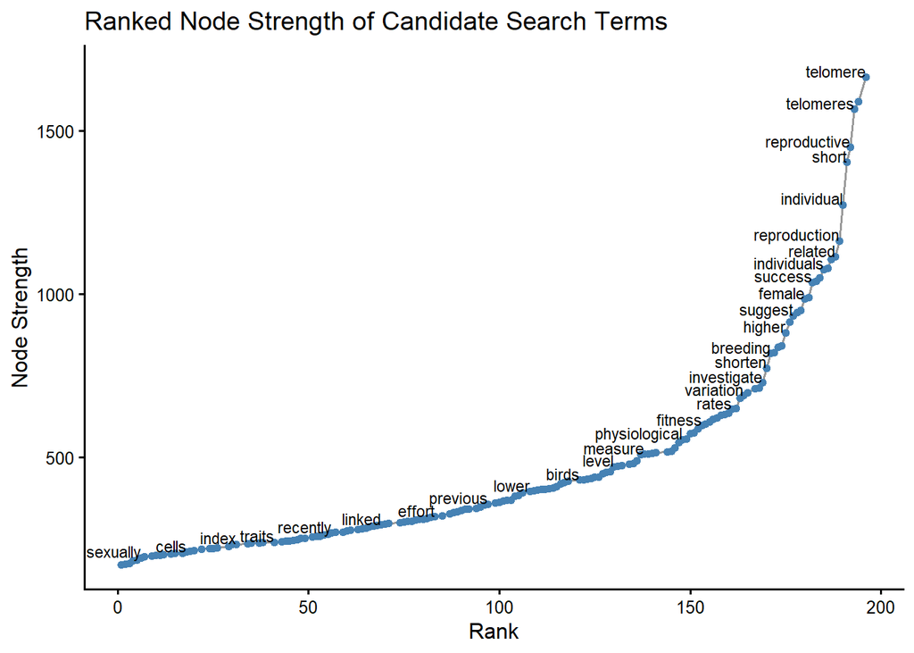

Figure 1. Ranked node strength of candidate search terms in the co-occurrence network. Labels are shown for terms ranked above 5.

```r
ggplot(term_strengths, aes(x = rank, y = strength, label = term)) +
  geom_line(colour = "grey60") +
  geom_point(colour = "steelblue") +
  geom_text(
    data      = dplyr::filter(term_strengths, rank > 5),
    hjust     = "right",
    nudge_y   = 20,
    check_overlap = TRUE,
    size      = 3
  ) +
  labs(
    title = "Ranked Node Strength of Candidate Search Terms",
    x     = "Rank",
    y     = "Node Strength"
  ) +
  theme_classic(base_size = 12)
```

## 6.3 Pruning the Network

A cumulative importance cutoff is applied to retain the top **80%** of cumulative node strength, reducing the network to the most informative terms only.

```r
cutoff <- litsearchr::find_cutoff(
  graph      = co_network,
  method     = "cumulative",
  percent    = 0.80,
  imp_method = "strength"
)

reduced_network  <- litsearchr::reduce_graph(
  graph            = co_network,
  cutoff_strength  = cutoff
)

suggested_terms <- litsearchr::get_keywords(reduced_network)
```

# 7 Supplementing Suggested Terms

The algorithmically suggested terms are supplemented with domain-specific terms identified through expert knowledge. These additional terms capture concepts related to **reproductive investment**, **life history trade-offs**, and **telomere dynamics** that may not have been sufficiently represented in the gold standard corpus.

```r
expert_terms <- c(
  # Reproductive biology
  "reproductive",        "reproductive aging",    "reproductive ageing",
  "reproductive quality","reproductive senescence","reproductive trade-offs",
  "reproductive success","reproductive costs",    "reproductive investment",
  "reproductive stress", "reproductive traits",   "reproductive output",
  "reproductive effort", "reproductive history",
  # Parental investment
  "parental",            "parental investment",   "parental costs",
  "parental quality",    "parental trade-offs",   "parental care",
  "parental effort",
  # Fitness and life history
  "fecundity",           "fertility",             "rearing",
  "life history",
  # Telomere dynamics
  "accelerated",         "erosion",               "markers",
  "attrition",           "lengthening",           "elongation",
  # Statistical/relational terms
  "correlate",           "associated",            "impact",
  "influence"
)

all_terms_sorted <- sort(unique(c(suggested_terms, expert_terms)))
```

> **Note:** The original script contained two typographical errors in the expert term list (`"lenghtening"` and `"imapct"`), which have been corrected to `"lengthening"` and `"impact"` above.

```r
write.csv(
  all_terms_sorted,
  file      = "sorted_terms.csv",
  row.names = FALSE
)
```

# 8 Writing the Boolean Search String

## 8.1 Loading and Grouping Terms

The sorted term list is read back in and terms are manually assigned to two conceptual groups: **telomeres** and **reproduction**. The indices below correspond to the positions of the relevant terms in the sorted list.

```r
sorted_terms <- read.csv("../data/sorted_terms.csv", header = TRUE)[[1]]

grouped_terms <- list(
  telomeres    = sorted_terms[c(72, 138, 142, 154, 155, 156, 157, 158)],
  reproduction = sorted_terms[c(
    15,  36,  39,  41,  63,  64,  86, 89, 90,  91,  92,
    93,  94,  95, 110, 116, 117, 118, 119, 120, 121,
   122, 123, 124, 125, 126, 127, 128, 129, 130
  )]
)
```

## 8.2 Generating the Search String

The Boolean search string is written to a text file with exact phrase matching and stemming enabled.

```r
litsearchr::write_search(
  grouped_terms,
  languages   = "English",
  exactphrase = TRUE,
  stemming    = TRUE,
  closure     = "none",
  writesearch = FALSE #change to TRUE if you are generating it for the first time
)
```

```
## [1] "English is written"
```

```
## [1] "((telomer*) AND (breed* OR fecund* OR fertil* OR fitness OR life-histori* OR \"life* histori*\" OR offspr* OR parent* OR rear* OR reproduct*))"
```

# 9 Importing and Merging Database Results

## 9.1 Defining Shared Columns

To enable merging across databases, only the four columns common to all sources are retained: `author`, `year`, `title`, and `abstract`.

```r
shared_columns <- c("author", "year", "title", "abstract")
```

## 9.2 Web of Science

Web of Science results were exported in two parts due to download limits and are imported and combined here.

```r
wos_part1 <- litsearchr::import_results(file = "../data/WoS_part1.ris")
```

```
## Reading file ../data/WoS_part1.ris ... done
```

```r
wos_part2 <- litsearchr::import_results(file = "../data/WoS_part2.ris")
```

```
## Reading file ../data/WoS_part2.ris ... done
```

```r
wos_combined <- rbind(
  wos_part1[shared_columns],
  wos_part2[shared_columns]
)
```

## 9.3 Scopus

```r
scopus <- litsearchr::import_results(file = "../data/Scopus.ris")
```

```
## Reading file ../data/Scopus.ris ... done
```

```r
scopus_selected <- scopus[shared_columns]
```

## 9.4 PubMed

PubMed exports use `date_published` rather than `year`; this column is renamed to match the shared schema before merging.

```r
pubmed <- litsearchr::import_results(file = "../data/PubMed_files.nbib")
```

```
## Reading file ../data/PubMed_files.nbib ... done
```

```r
pubmed_selected <- pubmed[c("author", "date_published", "title", "abstract")] %>%
  dplyr::rename(year = date_published)
```

## 9.5 Merging All Sources

```r
all_results <- rbind(wos_combined, scopus_selected, pubmed_selected)

cat("Total records before deduplication:", nrow(all_results), "\n")
```

```
## Total records before deduplication: 5464
```

# 10 Deduplication

Duplicate records are identified and removed based on **lowercase title matching**, which accounts for minor capitalisation differences across databases.

```r
all_results <- all_results %>%
  dplyr::mutate(title = tolower(title))

unique_results <- dplyr::distinct(all_results, title,.keep_all = TRUE)

unique_results <- unique_results %>%
  dplyr::mutate(
    author = sapply(author, function(x) paste(unlist(x), collapse = "; "))
  )

cat("Total records after deduplication:", nrow(unique_results), "\n")
```

```
## Total records after deduplication: 4292
```

# 11 Validating Gold Standard Recall

## 11.1 Pre-screening Validation

It is critical to verify that all gold standard papers are present in the merged dataset *before* abstract screening begins. Any missing papers indicate gaps in the search strategy that should be addressed.

You can add them manually to the list afterwards.

```r
gold_standard <- gold_standard %>%
  dplyr::mutate(
    title          = tolower(title),
    in_merged_data = title %in% unique_results$title
  )

missing_pre_screen <- gold_standard %>%
  dplyr::filter(!in_merged_data) %>%
  dplyr::select(title)

cat("Gold standard papers NOT found in merged dataset:",
    nrow(missing_pre_screen), "\n")
```

```
## Gold standard papers NOT found in merged dataset: 2
```

```r
if (nrow(missing_pre_screen) > 0) {
  print(missing_pre_screen)
}
```

```
## # A tibble: 2 × 1
##   title
##   <chr>
## 1 telomere length positively correlates with pace-of-life in a sex- and cohort-…
## 2 accelerated telomere shortening in response to life stress
```

## 11.2 Exporting the Deduplicated Article List

The deduplicated dataset is exported as a `.csv` file for use in the abstract screening stage (e.g., in Rayyan or Covidence).

```r
write.csv(
  unique_results,
  file      = "../data/articles_for_screening.csv",
  row.names = FALSE
)
```

# 12 Post-screening Validation

After abstract screening, a second validation step confirms that no gold standard papers were incorrectly excluded during the screening process.

```r
selected_papers <- readxl::read_excel("../data/selected_papers_29_01_24_tutorial.xlsx")

gold_standard <- gold_standard %>%
  dplyr::mutate(
    in_selected_papers = title %in% tolower(selected_papers$TITLE)
  )

missing_post_screen <- gold_standard %>%
  dplyr::filter(!in_selected_papers) %>%
  dplyr::select(title)

cat("Gold standard papers NOT found after abstract screening:",
    nrow(missing_post_screen), "\n")
```

```
## Gold standard papers NOT found after abstract screening: 1
```

```r
if (nrow(missing_post_screen) > 0) {
  print(missing_post_screen)
}
```

```
## # A tibble: 1 × 1
##   title
##   <chr>
## 1 nest cover and faecal glucocorticoid metabolites are linked to hatching succe…
```

# 14 Abstract Screening

## 14.1 Overview

Following the export of the deduplicated article list, abstracts are screened using the `metagear` package, which provides an interactive graphical interface for systematic review screening. This stage determines which articles are sufficiently relevant to proceed to full-text review.

## 14.2 Required Packages

```r
library(metagear)   # Abstract screening GUI
library(tidyverse)  # Data manipulation and import
```

## 14.3 Loading the Deduplicated Article List

The deduplicated article list produced in the previous stage is loaded for screening.

```r
articles_for_screening <- readr::read_csv(
  "../data/articles_for_screening.csv",
  show_col_types = FALSE
)

cat("Articles loaded for screening:", nrow(articles_for_screening), "\n")
```

```
## Articles loaded for screening: 4292
```

## 14.4 Standardising Column Names

The `metagear` abstract screener requires columns to follow a specific naming convention (`AUTHORS`, `TITLE`, `ABSTRACT`, `YEAR`). The column names are therefore standardised before initialising the screening workflow.

```r
articles_for_screening <- articles_for_screening %>%
  dplyr::rename(
    AUTHORS  = author,
    TITLE    = title,
    ABSTRACT = abstract,
    YEAR     = year
  )

# Verify column names
colnames(articles_for_screening)
```

```
## [1] "AUTHORS"  "YEAR"     "TITLE"    "ABSTRACT"
```

## 14.5 Initialising the Screening Effort

The `effort_distribute()` function initialises the screening workflow by assigning articles to one or more reviewers and saving a reviewer-specific `.csv` file. This step only needs to be run **once** to generate the screening file — it is therefore set to `eval=FALSE` to prevent it from re-running on each knit.

```r
articles_for_screening <- metagear::effort_distribute(
  articles_for_screening,
  initialize   = TRUE,
  reviewers    = "Agnes",
  save_split   = TRUE
)
```

> **Note:** Running this chunk will write a file named `effort_Agnes.csv` to your working directory. Open this file path in the screener below. This chunk should only be run **once** — re-running it will overwrite any screening progress already saved.

## 14.6 Running the Abstract Screener

The interactive abstract screener is launched using `abstract_screener()`. This opens a graphical interface in which each abstract can be marked as **YES** (include), **NO** (exclude), or **MAYBE** (uncertain).

Predefined keywords are highlighted in the interface to assist with rapid screening decisions. These keywords reflect the core concepts of the research question: telomere dynamics and reproductive investment.

This chunk is also set to `eval=FALSE` as the GUI cannot be launched during knitting.

```r
metagear::abstract_screener(
  file               = "effort_Agnes.csv",
  aReviewer          = "Agnes",
  highlightColor     = "palegoldenrod",
  highlightKeywords  = c(
    "telomere",
    "reproductive",
    "parental",
    "rearing",
    "fitness",
    "life history",
    "life histories"
  )
)
```

> **Screening instructions:**
> - Click **YES** to include an article for full-text review
> - Click **NO** to exclude an article
> - Click **MAYBE** to flag an article for a second opinion

> Progress is saved automatically to `effort_Agnes.csv` after each decision. Screening can be paused and resumed at any time by re-running this chunk.